# Chap 8.3

Mijeong Kim

```r
library(tsibble)
library(tsibbledata)
library(tibble)
library(dplyr)
library(knitr)
library(ggplot2)
library(fpp3)
library(fpp2)
library(seasonal)
library(feasts)
```

## 8.3 Methods with seasonality (계절성 기법)

#### Holt-Winters 방법 개요

Holt-Winters 방법은 Holt의 추세 모형을 계절성까지 확장한 것으로, 수준(level), 추세(trend), 계절성(seasonal) 세 가지 성분을 포함함. 각각은 평활계수 α, β*, γ로 업데이트된다. 여기서 m은 계절 주기(예: 분기=4, 월별=12)를 의미함.

Holt-Winters 방법의 두 가지 형태:

- **가법 모형 (Additive)**  
  계절 변동이 일정한 크기로 유지될 때 적합.  
  계절성은 관측값과 동일한 단위로 표현되며, 수준식에서 계절 성분을 빼서 조정함. 한 주기 내 계절 성분의 합은 약 0이 됨.
- **승법 모형 (Multiplicative)**  
  계절 변동이 수준에 비례하여 변할 때 적합.  
  계절성은 비율(%) 형태로 표현되며, 수준식에서 계절 성분으로 나누어 조정함. 한 주기 내 계절 성분의 합은 약 m이 됨.

### Holt-Winters 가법적 방법 식

- 예측:
  $$\hat{y}_{t+h|t} = \ell_t + h b_t + s_{t+h-m(k+1)}$$
- 수준 업데이트:
  $$\ell_t = \alpha (y_t - s_{t-m}) + (1-\alpha)(\ell_{t-1} + b_{t-1})$$
- 추세 업데이트:
  $$b_t = \beta^* (\ell_t - \ell_{t-1}) + (1-\beta^*)b_{t-1}$$
- 계절성 업데이트:
  $$s_t = \gamma (y_t - \ell_{t-1} - b_{t-1}) + (1-\gamma)s_{t-m}$$
- 보통 $\gamma^*$를 도입하여 $\gamma = \gamma^*(1-\alpha)$ 형태로 나타내기도 함.

### Holt-Winters 승법적 방법 식

- 예측:
  $$\hat{y}_{t+h|t} = (\ell_t + h b_t) s_{t+h-m(k+1)}$$
- 수준 업데이트:
  $$\ell_t = \alpha \frac{y_t}{s_{t-m}} + (1-\alpha)(\ell_{t-1} + b_{t-1})$$
- 추세 업데이트:
  $$b_t = \beta^* (\ell_t - \ell_{t-1}) + (1-\beta^*)b_{t-1}$$
- 계절성 업데이트:
  $$s_t = \gamma \frac{y_t}{\ell_{t-1}+b_{t-1}} + (1-\gamma)s_{t-m}$$

### 예시: 호주 국내 관광객 숙박

- 데이터: 1998–2017년 분기별 방문자 숙박일 수.
- 예측: 2018–2020년까지.
- 특징: 매년 3월 분기(March quarter)에 피크가 나타나는 명확한 계절성 존재 (호주 여름).

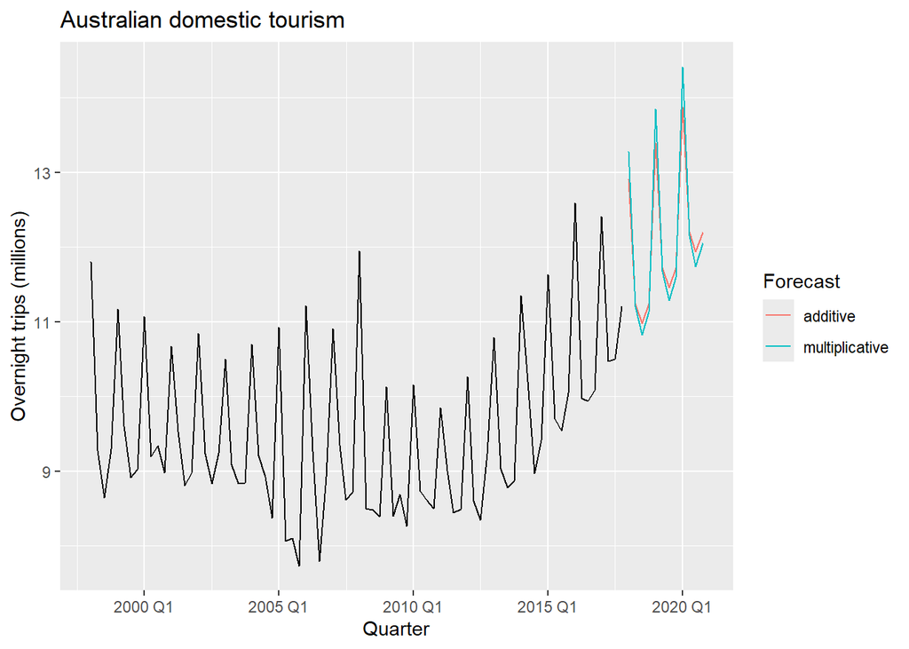

```r
aus_holidays <- tourism |>
  filter(Purpose == "Holiday") |>
  summarise(Trips = sum(Trips)/1e3)
fit <- aus_holidays |>
  model(
    additive = ETS(Trips ~ error("A") + trend("A") +
                                                season("A")),
    multiplicative = ETS(Trips ~ error("M") + trend("A") +
                                                season("M"))
  )
fc <- fit |> forecast(h = "3 years")
fc |>
  autoplot(aus_holidays, level = NULL) +
  labs(title="Australian domestic tourism",
       y="Overnight trips (millions)") +
  guides(colour = guide_legend(title = "Forecast"))
```

Figure 8.7: Forecasting domestic overnight trips in Australia using the Holt-Winters method with both additive and multiplicative seasonality.

#### 1. Holt-Winters 가법적(Additive) 방법

- 적용: 호주 국내 관광 데이터 예측.
- 평활 계수:
  - 수준(α) = 0.2620
  - 추세(β*) = 0.1646
  - 계절성(γ) = 0.0001
- RMSE = 0.4169
- 특징:
  - 계절 성분의 합이 **대략 0**에 가까움.
  - 예측 결과가 일정한 계절 패턴을 반영.

#### 2. Holt-Winters 승법적(Multiplicative) 방법

- 적용: 동일한 데이터에 대해 승법적 계절성 고려.
- 평활 계수:
  - 수준(α) = 0.2237
  - 추세(β*) = 0.1360
  - 계절성(γ) = 0.0001
- RMSE = 0.4122
- 특징:
  - 계절 성분의 합이 **대략 4**(m=4, 분기 데이터).
  - 승법적 모델이 가법적 모델보다 **약간 더 낮은 RMSE**를 보임 → **더 나은 적합**.

#### 3. 두 방법 비교

- 두 모델 모두 동일한 수의 파라미터를 가짐 → **RMSE 직접 비교 가능**.
- 승법적 모델이 **훈련 데이터에 약간 더 잘 적합**함.
- 승법 모델의 γ 값이 매우 작아 **계절 성분이 시간에 따라 거의 변하지 않음**.
- β* 값 또한 작아 **추세(기울기) 변화도 거의 없음**.

### Holt-Winters’ Damped Method

- **감쇠 추세(damped trend)**와 **승법적 계절성(multiplicative seasonality)**을 결합한 Holt-Winters 방법은  
  계절성이 있는 데이터에 대해 **정확하고 견고한 예측**을 제공할 수 있음.

#### 모형 식

- 예측:
  $$\hat{y}_{t+h|t} = \left[\ell_t + (\phi + \phi^2 + \cdots +
  \phi^h)b_t\right] s_{t+h-m(k+1)}$$
- 수준 업데이트:
  $$\ell_t = \alpha \left( \frac{y_t}{s_{t-m}} \right) +
  (1-\alpha)(\ell_{t-1} + \phi b_{t-1})$$
- 추세 업데이트:
  $$b_t = \beta^*(\ell_t - \ell_{t-1}) + (1-\beta^*)\phi b_{t-1}$$
- 계절성 업데이트:
  $$s_t = \gamma \frac{y_t}{\ell_{t-1} + \phi b_{t-1}} + (1-\gamma)s_{t-m}$$

### 예시: 일별 데이터 적용

- 데이터: **2016년 7월**, 호주 멜버른 기차역에서의 **보행자 수 데이터**.
- 설정:
  - 계절 주기 $m = 7$ (일주일 단위).
  - 예측 단위 $h$도 **일(day)** 단위로 설정.

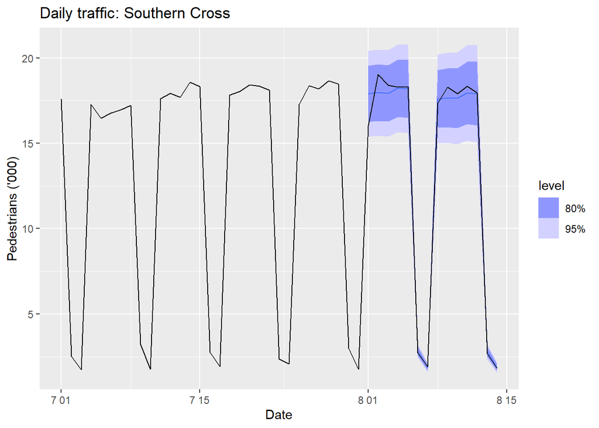

```r
sth_cross_ped <- pedestrian |>
  filter(Date >= "2016-07-01",
         Sensor == "Southern Cross Station") |>
  index_by(Date) |>
  summarise(Count = sum(Count)/1000)
sth_cross_ped |>
  filter(Date <= "2016-07-31") |>
  model(
    hw = ETS(Count ~ error("M") + trend("Ad") + season("M"))
  ) |>
  forecast(h = "2 weeks") |>
  autoplot(sth_cross_ped |> filter(Date <= "2016-08-14")) +
  labs(title = "Daily traffic: Southern Cross",
       y="Pedestrians ('000)")
```

Figure 8.9: Forecasts of daily pedestrian traffic at the Southern Cross railway station, Melbourne.

#### 모델 해석

- 모델이 **주간(weekly) 계절 패턴**과 **데이터 말미의 증가 추세**를 정확히 포착함.
- 예측 결과는 **테스트 데이터와 매우 잘 일치**함.